# Scaling methods

23 April 2018

This document gives some examples of how to apply scaling methods (Wordscores and Wordfish) in `R`. For theses example, we use the (English) speeches of EP group leaders that are part of the [EUSpeech](https://dataverse.harvard.edu/dataverse/euspeech) dataset. NB: Use setwd() to set the working directory to the folder that contains EP speeches in the file speeches_ep.csv.

```r
Sys.setlocale(locale = "en_US.UTF-8")
```

```
## [1] "en_US.UTF-8/en_US.UTF-8/en_US.UTF-8/C/en_US.UTF-8/C"
```

```r
#load libraries

library(readtext)
library(quanteda)
library(stringr)
library(ggplot2)

#read in the EP speeches
speeches <- readtext("speeches_ep.csv", text_field = "text", encoding = "UTF-8")

#let's do a bit of manual cleaning to remove some boiler plate terms
speeches$text <- str_replace_all(speeches$text, "ladies and gentlemen", " ")
speeches$text <- str_replace_all(speeches$text, "President", " ")
speeches$text <- str_replace_all(speeches$text, "Mr", " ")
speeches$text <- str_replace_all(speeches$text, "Council", " ")
speeches$text <- str_replace_all(speeches$text, "Commission", " ")

#take a look at how many unique speakers there are in the dataset
unique(speeches$speaker)
```

```
##  [1] "Lothar Bisky"         "Martin Callanan"      "Daniel Cohn-Bendit"
##  [4] "Brian Crowley"        "Joseph Daul"          "Marcel de Graaff"
##  [7] "Nigel Farage"         "Monica Frassoni"      "Rebecca Harms"
## [10] "Syed Kamall"          "Michal Kaminski"      "Philippe Lamberts"
## [13] "Cristiana Muscardini" "Martin Schulz"        "Kathy Sinnott"
## [16] "Francesco Speroni"    "Hannes Swoboda"       "Guy Verhofstadt"
## [19] "Graham Watson"        "Francis Wurtz"        "Jan Zahradil"
## [22] "Gabriele Zimmer"
```

Let’s first append the speeches for each speaker into using the `dplyr` library. If you don’t have `dplyr` installed, do so using the `install.packages()` function.

```r
library(dplyr)

#the `%>%` command is the pipe function and helps us with a chain of functions
#think of it as `then`:
#take the speeches dataframe, then
#group by variable, then
#paste speeches together.

speeches <- speeches %>%
  group_by(speaker) %>%
  summarise(text = paste(text, collapse = " ")) %>%
  ungroup()

#confirm that you have a total of 22 (very long) concatenated speeches, 1 for each EP speaker
```

Wordscores and Wordfish take in a dfm as input, so first we will need to turn the speeches into a dfm:

```r
speeches <- corpus(speeches)

#create a dfm
speeches.dfm <- dfm(speeches, stem = TRUE, remove=stopwords("english"), remove_punct=TRUE, ngrams = 1,  remove_numbers = TRUE)

#include only thoses features that occur in at least 5 documents
speeches.dfm <- dfm_trim(speeches.dfm, min_docfreq = 5)

#chech the number of documents and features
dim(speeches.dfm)
```

```
## [1]   22 3598
```

```r
#change the document names to the speaker names
docnames(speeches.dfm) <- docvars(speeches.dfm, "speaker")
```

## Wordscores

Let’s see if we can use Wordscores to locate these 22 speakers on a pro-anti EU dimension. We’ll first need to determine reference texts to anchor this dimension. On the anti-EU side we’ll locate Nigel Farage, for obvious reasons, and on the pro-EU dimension we’ll locate Guy Verhofstadt, leader of the liberal ALDE group, and a visible federalist:

```r
#append an empty reference.score variable to the speeches.dfm data.frame
docvars(speeches.dfm, "reference.score") <- NA

#locate which rows correspond with Guy Verhofstadt and Nigel Farage and call these numbers pro.eu and anti.eu respectively
pro.eu <- which(docvars(speeches.dfm) == "Guy Verhofstadt")
anti.eu <- which(docvars(speeches.dfm) == "Nigel Farage")

#assign reference scores to Guy Verhofstadt (-1) and Nigel Farage (+1)
docvars(speeches.dfm, "reference.score")[pro.eu] <- 1
docvars(speeches.dfm, "reference.score")[anti.eu] <- -1

#inspects the reference.score variable:
docvars(speeches.dfm, "reference.score")
```

```
##  [1] NA NA NA NA NA NA NA  1 NA NA NA NA NA NA NA NA NA NA -1 NA NA NA
```

```r
speeches.wordscores <- textmodel_wordscores(speeches.dfm, y = docvars(speeches.dfm, "reference.score"), scale = c("linear"), smooth = 0)
summary(speeches.wordscores, 10)
```

```
##
## Call:
## textmodel_wordscores.dfm(x = speeches.dfm, y = docvars(speeches.dfm,
##     "reference.score"), scale = c("linear"), smooth = 0)
##
## Reference Document Statistics:
##                      score total min max     mean median
## Brian Crowley           NA 14350   0 191  3.98833    1.0
## Cristiana Muscardini    NA  8293   0  88  2.30489    0.0
## Daniel Cohn-Bendit      NA 18854   0 302  5.24013    1.0
## Francesco Speroni       NA 15598   0 218  4.33519    1.0
## Francis Wurtz           NA 11028   0 201  3.06504    1.0
## Gabriele Zimmer         NA  5598   0 132  1.55586    0.0
## Graham Watson           NA 16070   0 194  4.46637    1.0
## Guy Verhofstadt          1 42886   0 818 11.91940    2.0
## Hannes Swoboda          NA 34239   0 445  9.51612    2.0
## Jan Zahradil            NA  5628   0 125  1.56420    0.0
## Joseph Daul             NA 40190   0 890 11.17009    2.0
## Kathy Sinnott           NA 13582   0 159  3.77487    1.0
## Lothar Bisky            NA  9608   0 135  2.67037    0.0
## Marcel de Graaff        NA    58   0   3  0.01612    0.0
## Martin Callanan         NA 15662   0 185  4.35297    1.0
## Martin Schulz           NA 55291   0 936 15.36715    3.5
## Michal Kaminski         NA 19695   0 341  5.47387    1.0
## Monica Frassoni         NA 10694   0 165  2.97221    1.0
## Nigel Farage            -1 23885   0 336  6.63841    1.0
## Philippe Lamberts       NA   492   0  11  0.13674    0.0
## Rebecca Harms           NA 18632   0 313  5.17843    1.0
## Syed Kamall             NA  6599   0  99  1.83407    0.0
##
## Wordscores:
## (showing first 10 elements)
##   in-offic       meet       take      place       next      month
##    0.05387    0.56419    0.01042   -0.45012   -0.10081    0.26470
## particular      focus     econom     affair
##   -0.61011    0.32187    0.23829    0.86079
```

```r
#sort most discriminant words:

#pro-EU
head(sort(speeches.wordscores$wordscores), 10)
```

```
##      bite      star    wisdom  strength  lifelong      cycl     white
##        -1        -1        -1        -1        -1        -1        -1
##    caught    disabl psycholog
##        -1        -1        -1
```

```r
#anti-EU
tail(sort(speeches.wordscores$wordscores), 10)
```

```
##  influenti     deepen      forth   stricter wholeheart     offens
##          1          1          1          1          1          1
##    registr insignific   outbreak       unif
##          1          1          1          1
```

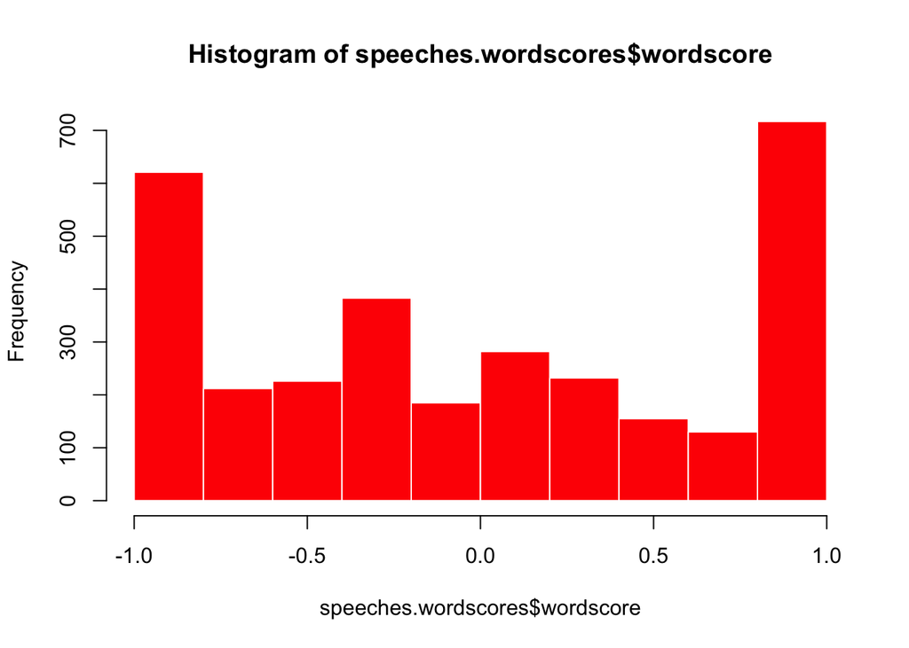

```r
#histogram of wordscores
hist(speeches.wordscores$wordscore, col = "red", border = 0)
```

How would you interpret this histogram? And why do we see these peaks at -1 and at 1? How would you interpret the pro-EU and anti-EU discriminant words. Do they make sense?

Let’s use the Wordscores model to predict the document scores of the speeches of the 20 remaining group leaders

```r
speeches.wordscores.predict <- predict(speeches.wordscores, newdata = speeches.dfm)

#which speakers are most like Verhofstadt
speeches.wordscores.predict[order(speeches.wordscores.predict, decreasing = FALSE)][1:5]
```

```
## Francesco Speroni      Nigel Farage   Martin Callanan     Kathy Sinnott
##       -0.23198431       -0.22936963       -0.03416228       -0.02166856
##  Marcel de Graaff
##       -0.01735014
```

```r
#which speakers are most like Farage
speeches.wordscores.predict[order(speeches.wordscores.predict, decreasing = TRUE)][1:5]
```

```
##      Guy Verhofstadt          Joseph Daul      Monica Frassoni
##           0.22936963           0.10928470           0.09672047
## Cristiana Muscardini        Rebecca Harms
##           0.09070658           0.08857161
```

Visualize the document scores in a plot:

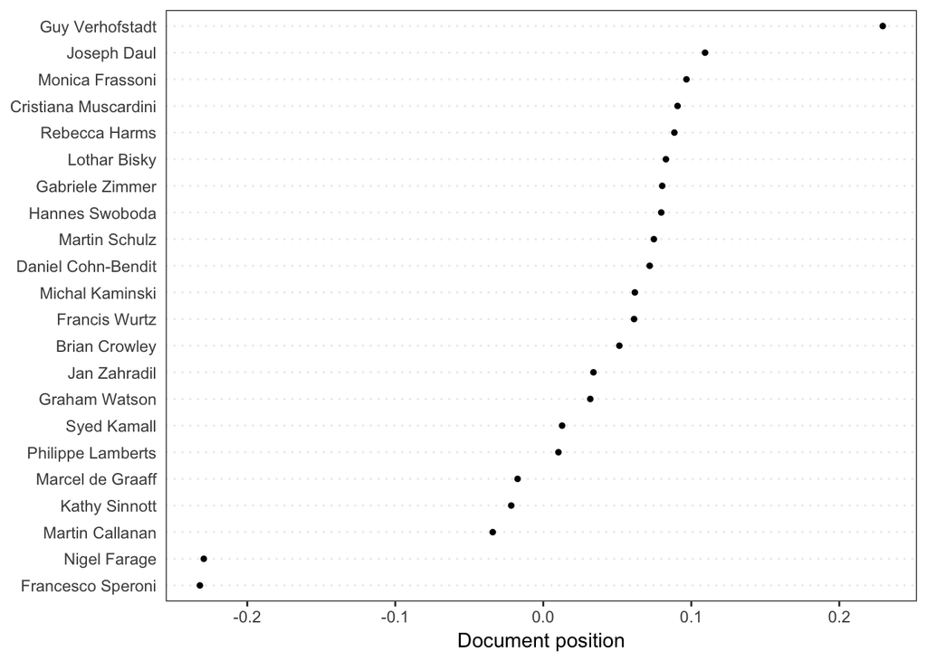

```r
#standard plot in quanteda
textplot_scale1d(speeches.wordscores.predict)
```

How would you interpret this outcome?

## Wordfish

Estimate a Wordfish model and inspect its output:

```r
speeches.wordfish <- textmodel_wordfish(speeches.dfm)
summary(speeches.wordfish)
```

```
##
## Call:
## textmodel_wordfish.dfm(x = speeches.dfm)
##
## Estimated Document Positions:
##                        theta       se
## Brian Crowley         0.6157 0.017337
## Cristiana Muscardini  1.0289 0.018033
## Daniel Cohn-Bendit   -0.2669 0.018230
## Francesco Speroni    -2.5794 0.019759
## Francis Wurtz         0.5547 0.020228
## Gabriele Zimmer       0.7197 0.026546
## Graham Watson         0.4312 0.017427
## Guy Verhofstadt      -0.4401 0.012293
## Hannes Swoboda        0.2336 0.012535
## Jan Zahradil         -0.1282 0.032813
## Joseph Daul           0.6932 0.010031
## Kathy Sinnott         1.1844 0.012299
## Lothar Bisky          0.4741 0.022252
## Marcel de Graaff     -0.2060 0.310380
## Martin Callanan      -0.8725 0.020895
## Martin Schulz         0.3077 0.009703
## Michal Kaminski       1.2523 0.009538
## Monica Frassoni       0.5753 0.020391
## Nigel Farage         -2.3500 0.016323
## Philippe Lamberts    -0.7762 0.116602
## Rebecca Harms         0.2368 0.016980
## Syed Kamall          -0.6886 0.031889
##
## Estimated Feature Scores:
##      in-offic   meet     take    place    next   month particular  focus
## beta   0.7186 0.1469 -0.04461 -0.01057 -0.2029 -0.1475     0.3343 0.4318
## psi    2.2407 2.9022  4.28933  3.28077  3.1167  3.0456     3.3674 2.1347
##        econom affair european    union propos   must   creat return
## beta -0.02604 0.2794  0.04923 -0.09904 0.1039 0.2841 0.09113 0.1291
## psi   4.06075 2.2588  5.59356  4.79480 3.7768 4.6733 3.16253 2.1559
##      economi previous    state implement immedi restart    today  speak
## beta 0.08047 -0.03205 0.005275    0.6603 0.2766  0.3533 -0.04636 0.2788
## psi  3.14430  1.63663 4.681989    2.3127 1.8333 -0.7517  4.10573 2.8048
##       futur   europ   peopl   claim   care    much
## beta 0.1983 0.01355 -0.2333 -0.1656 0.1138 -0.1555
## psi  3.4209 5.10194  4.7700  1.5039 2.0877  3.3757
```

```r
#generate a dataframe with word level parameters beta and psi
wordfish.word.data <- data.frame(beta = speeches.wordfish$beta,
                            psi = speeches.wordfish$psi,
                            features = speeches.wordfish$features)

dim(wordfish.word.data)
```

```
## [1] 3598    3
```

```r
head(wordfish.word.data)
```

```
##          beta      psi features
## 1  0.71864880 2.240720 in-offic
## 2  0.14685351 2.902177     meet
## 3 -0.04460659 4.289334     take
## 4 -0.01057309 3.280774    place
## 5 -0.20291491 3.116711     next
## 6 -0.14746563 3.045573    month
```

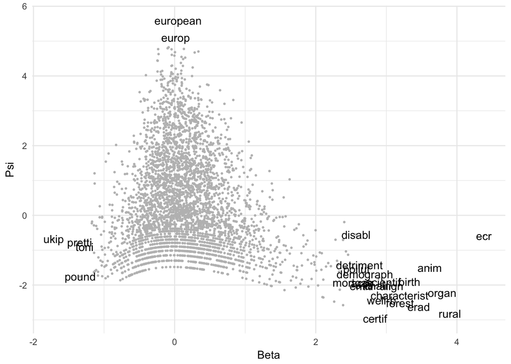

```r
word.plot <- ggplot(data = wordfish.word.data, aes(x = beta, y = psi))
word.plot <- word.plot + geom_point(size = .5, color = "grey") + labs(x = "Beta", y = "Psi") + guides(size = "none", color = guide_legend("")) + theme_minimal()
word.plot <- word.plot + geom_text(data=subset(wordfish.word.data, beta > 2.5 | beta < -1.25 | psi > 5),  aes(x = beta, y = psi, label = features))
print(word.plot)
```

How would you interpret the word plot?

Plot the document positions generated by Wordfish:

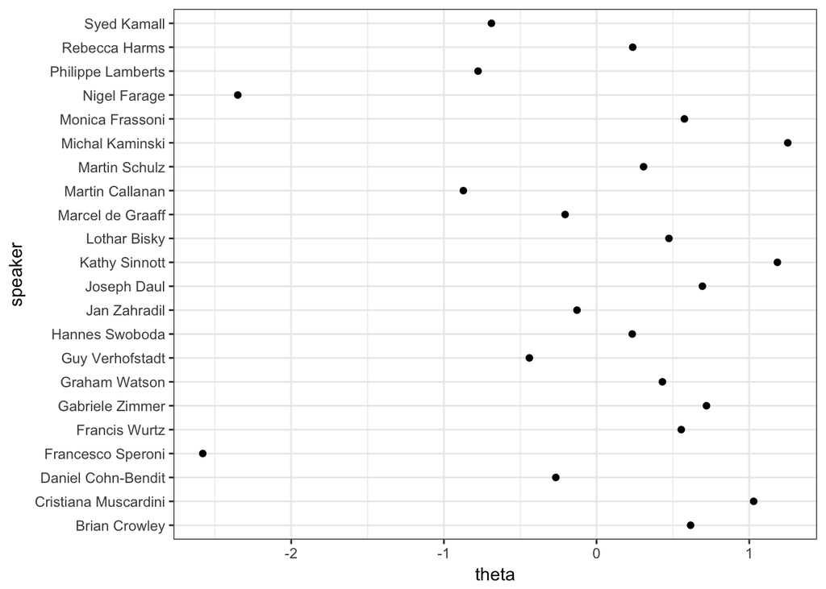

```r
#generate a dataframe with document level alpha beta and omega
wordfish.document.data <- data.frame(alpha = speeches.wordfish$alpha,
                                     theta = speeches.wordfish$theta,
                                     speaker = speeches.wordfish$docs)

#plot wordfish results using ggplot2
wordfish.plot <- ggplot(wordfish.document.data, aes(x= theta, y = speaker))
wordfish.plot <- wordfish.plot + geom_point() + theme_bw()
print(wordfish.plot)
```

Both Wordscores and Wordfish are scaling models and estimated on the same text data they should lead to similar results. Let’s see if this indeed the case.

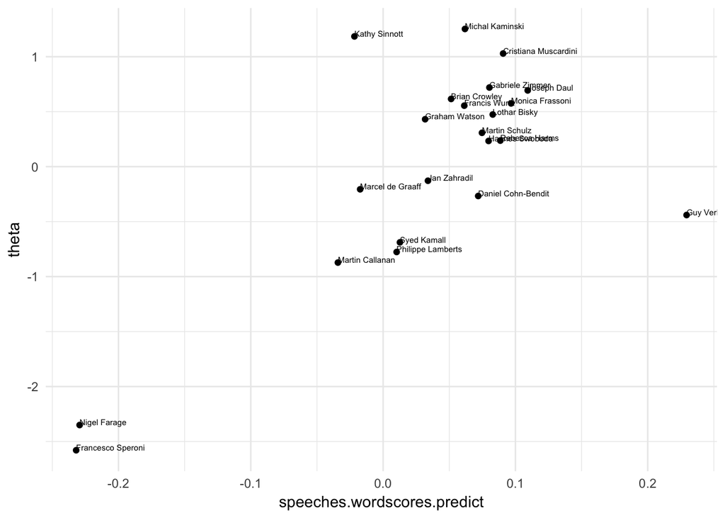

```r
scaling.data <- rbind(data.frame(speeches.wordscores.predict, wordfish.document.data))

scaling.plot <- ggplot(scaling.data, aes(x = speeches.wordscores.predict, y = theta, label = speaker))
scaling.plot <- scaling.plot + geom_point() + theme_minimal() + geom_text(aes(label=speaker),hjust=0, vjust=0, size = 2)
print(scaling.plot)
```

```r
correlation <- cor.test(x=scaling.data$speeches.wordscores.predict, y=scaling.data$theta, method = 'pearson')
print(correlation)
```

```
##
##  Pearson's product-moment correlation
##
## data:  scaling.data$speeches.wordscores.predict and scaling.data$theta
## t = 4.6916, df = 20, p-value = 0.0001401
## alternative hypothesis: true correlation is not equal to 0
## 95 percent confidence interval:
##  0.4349697 0.8776173
## sample estimates:
##       cor
## 0.7238361
```

How would you interpret this correlation?

## Additional assignment

Note that Wordscores are calculated from their relative occurrences in the reference texts. We currently have two reference texts (Verhofstadt and Farage). Change the code to add Francesco Speroni, and Italian anti-EU group leader, as a third reference text and run the code. How does it alter the results, if at all?